# Cuantificando conectividad por transporte público

HAVB

3/8/2021

## Objetivo

*Encontrar el grado de conectividad que tiene cada parque con los diferentes distritos de su ciudad*

Pasos a automatizar:

- Obtener el radio de influencia (300m) de las líneas de colectivos.
- Relacionar las líneas de colectivo totales con la posición de cada parque. Objetivo: Identificar que líneas se encuentran a 300m o menos del parque a analizar.
- Relacionar las líneas que llegan a cada parque con las que llegan a cada distrito.
- Obtener la relación entre el área total de cada distrito con el área de cobertura de las líneas que conectan con determinado parque. (El área de cobertura se obtiene a partir de su radio de influencia -300m-)
- Con los porcentajes de cada distrito se clasifica en CONECTIVIDAD BUENA, MEDIA, MALA.

### Librerías a utilizar

```r
library(dplyr)     # Manipulación/transformación de datos tabulares
library(purrr)     # Funciones auxiliares para iteración
library(ggplot2)   # Generación de visualizaciones
library(sf)        # Procesamiento de datos georeferenciados
```

## Implementación

### Identificación de grandes parques

Para la ciudad de interés -aglomerado Gran Rosario en este caso-, determinamos los espacios verdes de una superficie mayor a las 10 hectáreas (100.000 m2)

Cargamos la capa con los límites de los distritos de la región de interés

```r
distritos <- read_sf("../../Rosario/data/DISTRITOS/0Distritos Descentralizados.shp")
```

Extraemos de la base nacional de espacios verdes aquellos que superan el umbral de 10 Ha, y coinciden con la región de análisis

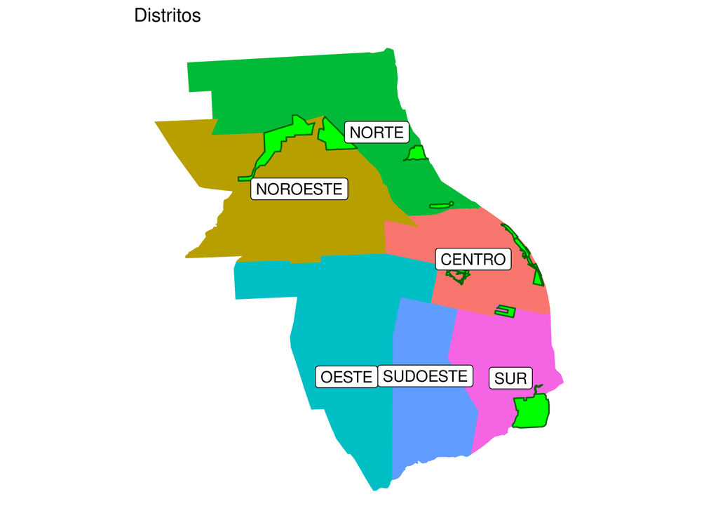

```r
tamanio_minimo_m <- 10^5

grandes_parques <- read_sf("../../data/processed/osm/areas_verdes_urbanas_argentina.shp") %>%
    st_transform(st_crs(distritos)) %>%
    filter(st_intersects(., st_union(distritos), sparse = FALSE),
           as.numeric(st_area(.)) > tamanio_minimo_m)

ggplot(distritos) +
    geom_sf(aes(fill = DISTRITO), color = NA) +
    geom_sf(data = grandes_parques, fill = "green", color = "darkgreen") +
    geom_sf_label(aes(label = DISTRITO)) +
    guides(fill = FALSE) +
    labs(title = "Distritos") +
    theme_void()
```

### Definición de áreas de cobertura de transporte público

Sumamos la capa de líneas de transporte

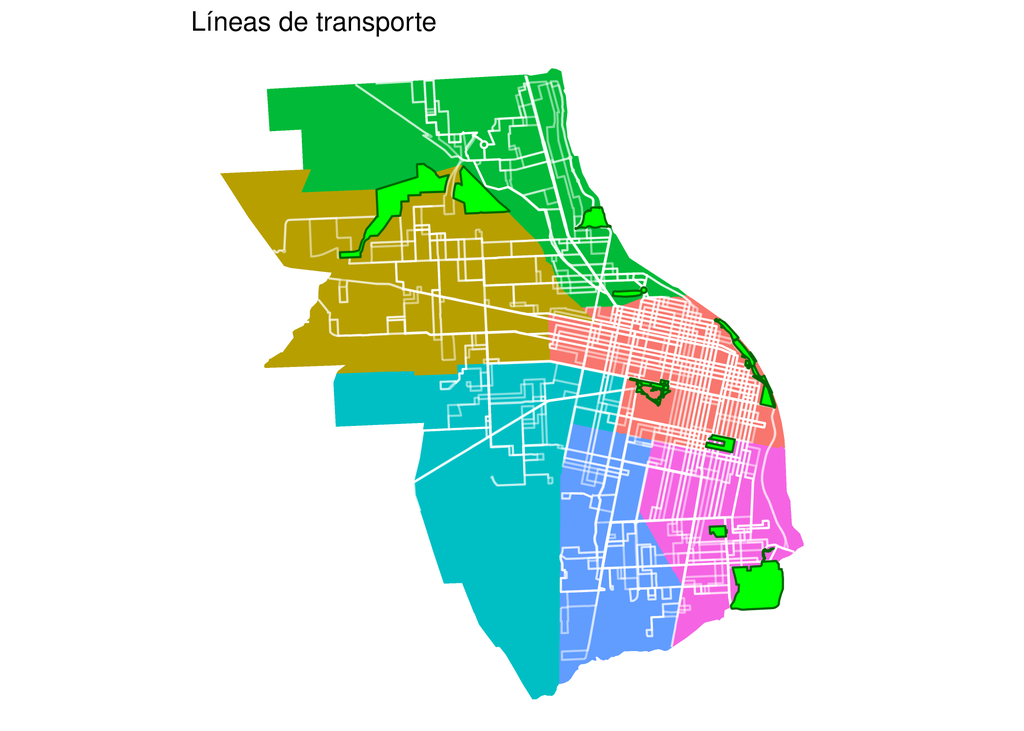

```r
lineas <- read_sf("../../Rosario/data/LINEAS Y TRANSPORTE/Recorridos TUP.shp")

ggplot(distritos) +
    geom_sf(aes(fill = DISTRITO), color = NA) +
    geom_sf(data = lineas, alpha = .5, color = "white") +
    geom_sf(data = grandes_parques, fill = "green", color = "darkgreen") +
    guides(fill = FALSE) +
    labs(title = "Líneas de transporte") +
    theme_void()
```

Definimos el área de cobertura de cada línea como el *buffer* de 300 metros a su alrededor

```r
lineas_cobertura <- st_buffer(lineas, 300)
```

### Identificación de grado de conectividad

Realizamos la cuantificación de conectividad:

- Identificamos, para cada pareja (distrito - gran parque), las líneas que los conectan - aquellas cuya área de cobertura intersecta con ambos.
- Luego calculamos que porcentaje del distrito es cubierto por las líneas que lo conectan con cada parque. Ese será su grado de conectividad
- Por último realizamos un índice que clasifica el grado de accesibilidad a nivel parque:
  - BUENA, cuando al menos 8 de cada 10 distritos presentan una cobertura > 70% para ese parque,
  - MEDIA, cuando al menos la mitad de los distritos presentan una cobertura > 70%,
  - MALA, cuando menos de la mitad de los distritos presenta una cobertura > 70%.

Creamos una función para encontrar conexiones:

```r
lineas_conectoras <- function(areaA, areaB, lineas) {

    # Unificamos proyección
    areaA <- st_transform(areaA, st_crs(lineas))
    areaB <- st_transform(areaB, st_crs(lineas))

    idx_conectoras <- st_intersects(lineas, areaA, sparse = FALSE) &
        st_intersects(lineas, areaB, sparse = FALSE)

    lineas[idx_conectoras,]
}
```

La probamos usando el primer parque en nuestros datos contra el primer distrito:

```r
lineas_conectoras(distritos[1,], grandes_parques[1,], lineas_cobertura)
```

| gml_id | SE_ROW_ID | LINEA | BANDERA | SENTIDO | ID_TUP | LINEA_BAND | TIPO | FECHA_HORA | OBSERVACIO | HORARIO1 | ID_RAMAL | geometry |
| --- | --- | --- | --- | --- | --- | --- | --- | --- | --- | --- | --- | --- |
| recorridos_tup.7063 | 7063 | 106 | 106 Ibarlucea I | Ida | 55 | 106 Ibarlucea | 1 | 2012-09-17 | Recorrido dispuesto por Resolución Nº 118/2012 Fecha de Implementación: 17/09/2012 | Funcionamiento: Días hábiles 6:00 hs a 22:00 hs | 7 |  |
| recorridos_tup.7064 | 7064 | 106 | 106 Ibarlucea V | Vuelta | 56 | 106 Ibarlucea | 1 | 2012-09-17 | Recorrido dispuesto por Resolución Nº 118/2012 Fecha de Implementación: 17/09/2012 | Funcionamiento: Días hábiles 6:00 hs a 22:00 hs | 7 |  |
| recorridos_tup.7065 | 7065 | 106 | 106 Municipal I | Ida | 57 | 106 Municipal | 1 | 2012-09-17 | Recorrido dispuesto por Resolución Nº 118/2012 Fecha de Implementación: 17/09/2012 | Funcionamiento: Días hábiles 6:00 hs a 22:00 hs | 8 |  |
| recorridos_tup.7066 | 7066 | 106 | 106 Municipal V | Vuelta | 58 | 106 Municipal | 1 | 2012-09-17 | Recorrido dispuesto por Resolución Nº 118/2012 Fecha de Implementación: 17/09/2012 | Funcionamiento: Días hábiles 6:00 hs a 22:00 hs | 8 |  |
| recorridos_tup.7067 | 7067 | 107 | 107 Negra Vuelt | Vuelta | 60 | 107 Negra | 1 | 2012-09-17 | Recorrido dispuesto por Resolución Nº 119/2012 Fecha de Implementación: 17/09/2012 | Funcionamiento: Días hábiles 6:00 hs a 22:00 hs | 9 |  |
| recorridos_tup.7068 | 7068 | 107 | 107 Roja Vuelta | Vuelta | 62 | 107 Roja | 1 | 2012-09-17 | Recorrido dispuesto por Resolución Nº 119/2012 Fecha de Implementación: 17/09/2012 | Funcionamiento: Días hábiles 6:00 hs a 22:00 hs | 10 |  |
| recorridos_tup.7069 | 7069 | 113 | 113 Ida | Ida | 69 | 113 | 1 | 2012-09-30 | Recorrido dispuesto por Resolución Nº 116/2012 Fecha de Implementación: 30/09/2012 | Funcionamiento: Días hábiles 6:00 hs a 22:00 hs | 14 |  |
| recorridos_tup.7102 | 7102 | 143 | 143 Roja Vuelta | Vuelta | 146 | 143 Roja | 1 | 2012-07-01 | Recorrido dispuesto por Resolución Nº 88/2012 Fecha de Implementación: 01/07/2012 | Funcionamiento: Días hábiles 6:00 hs a 22:00 hs | 49 |  |
| recorridos_tup.7127 | 7127 | 141 | 141 Ida | Ida | 135 | 141 | 1 | 2013-08-13 | Recorrido dispuesto por Resolución Nº 105/2012 Fecha de implementación: 13/08/2013 | Funcionamiento: Días hábiles 6:00 hs a 22:00 hs | 44 |  |
| recorridos_tup.7145 | 7145 | 143 | 143 Negra Vuelt | Vuelta | 144 | 143 Negra | 1 | 2015-07-14 | Recorrido dispuesto por Resolución Nº 079/2015 Fecha de Implementación: 14/07/2015 | Funcionamiento: Días hábiles 6:00 hs a 22:00 hs | 48 |  |

[output cut: 7 more lines]

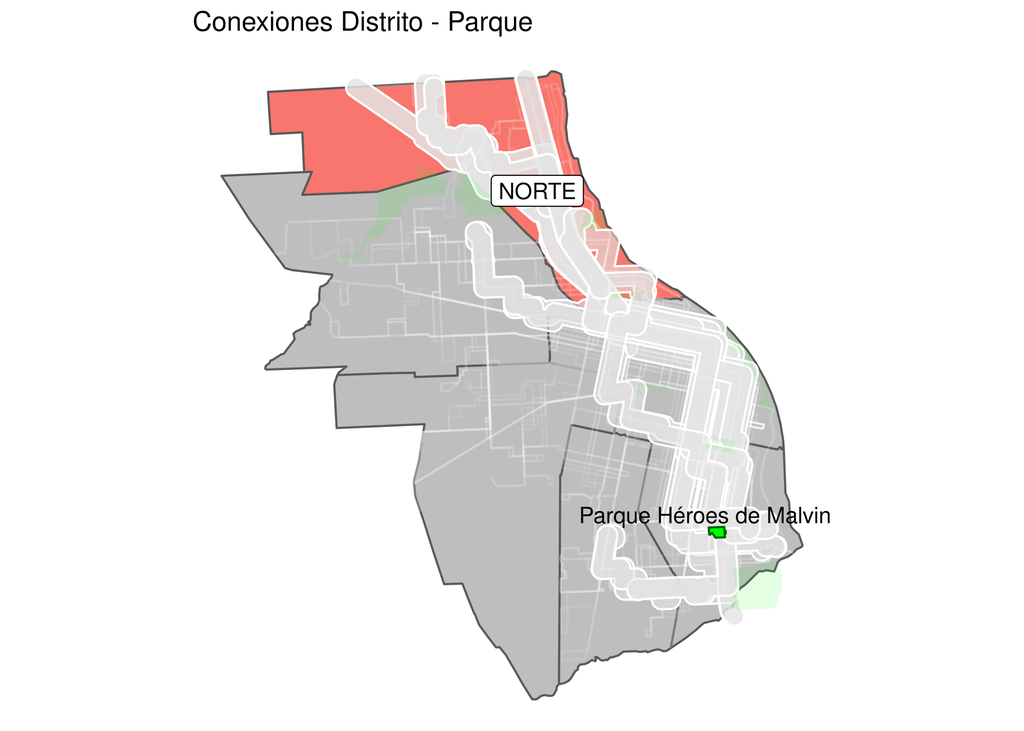

```r
ggplot() +
    geom_sf(data = distritos, fill = "gray") +
    geom_sf(data = distritos[1,], aes(fill = DISTRITO)) +
    geom_sf(data = lineas, alpha = .1, color = "white") +
    geom_sf(data = lineas_conectoras(distritos[1,], grandes_parques[1,], lineas_cobertura), alpha = .6, color = "white") +
    geom_sf(data = grandes_parques, fill = "green", color = NA, alpha = .1) +
    geom_sf(data = grandes_parques[1,], fill = "green", color = "darkgreen") +
    geom_sf_label(data = distritos[1,], aes(label = DISTRITO)) +
    geom_sf_text(data = grandes_parques[1,], aes(label = name), nudge_y = 500) +
    guides(fill = FALSE) +
    labs(title = "Conexiones Distrito - Parque") +
    theme_void()
```

### Medición de conectividad para los parques

Definimos una función de cuantificación que encuentre las lineas conectoras entre parque y distrito, y mida el porcentaje del distrito que recibe cobertura.

```r
medir_cobertura <- function(origen, destino, lineas) {

    # unificamos CRS pro las dudas
    origen <- st_transform(origen, st_crs(destino))

    # Identificamos lineas conectoras
    conectoras <- lineas_conectoras(origen, destino, lineas)

    as.numeric(st_area(st_union(st_intersection(origen, conectoras)))) /
        as.numeric(st_area(st_union(origen)))
}
```

Para la pareja Parque / Distrito que graficamos antes, el cáluclo nos da una cobertura cercana al 45.9%

```r
medir_cobertura(distritos[1,], grandes_parques[1,], lineas_cobertura)
```

```
## [1] 0.4585701
```

Ahora definimos una función que utilice a las anteriores para determinar la conectividad general de cada parque contra todos los distritos, y calificarla de acuerdo a la regla detallada antes.

```r
medir_conectividad <- function(destinos, origenes, lineas, etiquetas = TRUE) {

    aplicar_etiqueta <- function(porcentajes_cobertura) {
        case_when((sum(porcentajes_cobertura >= .7) / length(porcentajes_cobertura)) >= .8 ~ "BUENA",
                  (sum(porcentajes_cobertura >= .7) / length(porcentajes_cobertura)) >= .5 ~ "MEDIA",
                  (sum(porcentajes_cobertura >= .7) / length(porcentajes_cobertura)) < .5  ~ "MALA" )
    }

    cobertura_a_destino <- function(destino, origenes, lineas) {
        map_dbl(split(origenes, seq(nrow(origenes))), medir_cobertura, destino, lineas)
    }

    cobertura_todos_destinos <- map(split(destinos, seq(nrow(destinos))), cobertura_a_destino, origenes, lineas)

    if (etiquetas) {
        map_chr(cobertura_todos_destinos, aplicar_etiqueta)
    } else  {
        cobertura_todos_destinos
    }

}
```

Con eso podemos aplicar a cada parque su atributo de nivel de conectividad en un sólo paso

```r
grandes_parques$conectividad <- medir_conectividad(origenes = distritos,
                                                   destinos = grandes_parques,
                                                   lineas = lineas_cobertura)
```

En el mapa:

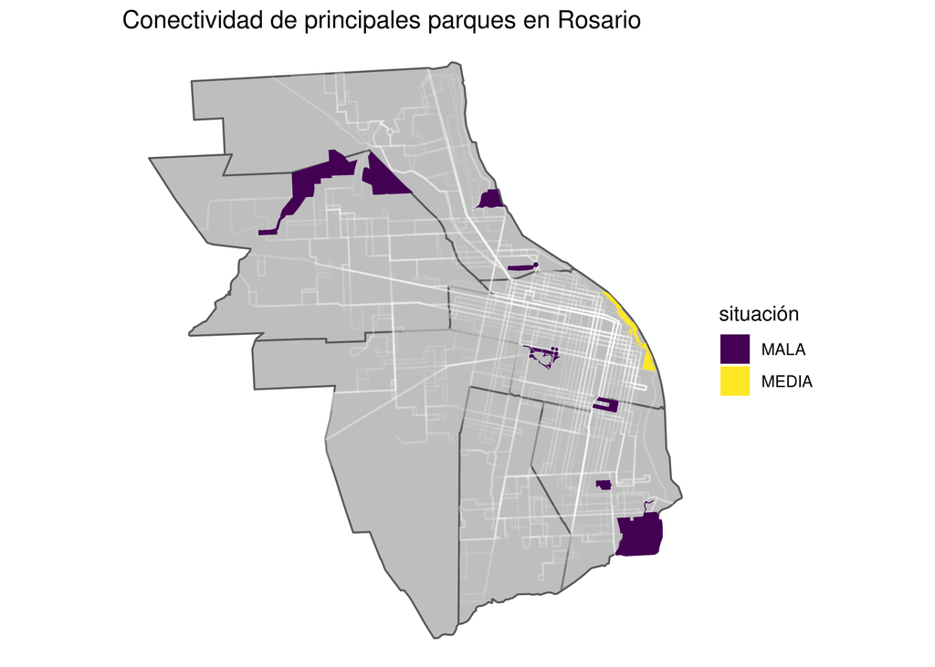

```r
ggplot() +
    geom_sf(data = distritos, fill = "gray") +
    geom_sf(data = lineas, alpha = .1, color = "white") +
    geom_sf(data = grandes_parques,
            aes(fill = ordered(conectividad, levels = c("MALA", "MEDIA", "BUENA"))),
            color = NA) +
    theme_void() +
    labs(title = "Conectividad de principales parques en Rosario", fill = "situación")
```

Si queremos espiar como es que se llegó a esa situación, podemos usar la opción de deshabilitar el etiquetado en la función `medir_conectividad`, para que en lugar de una calificación nos devuelva los valores en crudo de % de cobertura para cada distrito:

```r
tabla <- medir_conectividad(origenes = distritos,
                            destinos = grandes_parques,
                            lineas = lineas_cobertura,
                            etiquetas = FALSE)

tabla %>%
    as_data_frame() %>%
    round(3) %>%
    {. * 100} %>%
    setNames(grandes_parques$name) %>%
    {cbind(distrito = distritos$DISTRITO, .)}
```

| distrito | Parque Héroes de Malvinas | Parque Regional Villa Gobernador Gálvez, Parque Regional Sur "Dr. Carlos Silvestre Begnis" | Plaza Biblioteca C. Vigil, Plaza Che Guevara, Plaza Lucio Fontana, Plaza Juan Ingalinella, Plaza Martín Güemes, Parque Hipólito Yrigoyen, Plaza Dr. J. Enrique Ingallinella | Parque Margarita de Carlés, Plaza Luis Lamas, Paseo El Salvador, Palomar, Plaza de la Lealtad, Plaza Dalmacio Vélez Sarsfield, Plazoleta Emilia Bertolé, Plazoleta Campaña del Desierto | Parque Urquiza, Plaza Barrancas de las Ceibas, Plaza Monseñor M. de Andrea, Plazoleta Soberanía Nacional, Plaza Guernica, Plaza Perú, Parque de España, Parque Nacional de la Bandera, Anexo Parque Naci… | Parque Scalabrini Ortiz, Plaza Carlos M. Della Paolera | Don Ángel Tulio Zof | Bosque de los Constituyentes |
| --- | --- | --- | --- | --- | --- | --- | --- | --- |
| NORTE | 45.9 | 23.2 | 48.0 | 40.2 | 62.7 | 62.2 | 55.3 | 38.8 |
| NOROESTE | 20.8 | 40.7 | 51.5 | 6.7 | 62.5 | 30.2 | 26.0 | 45.9 |
| CENTRO | 72.6 | 71.7 | 91.4 | 83.8 | 97.8 | 85.7 | 84.3 | 74.3 |
| SUDOESTE | 19.5 | 13.7 | 59.4 | 43.3 | 81.8 | 52.4 | 32.4 | 13.9 |
| OESTE | 17.5 | 20.4 | 27.8 | 33.4 | 40.0 | 14.4 | 12.9 | 5.9 |
| SUR | 68.8 | 67.9 | 85.2 | 48.9 | 89.3 | 82.2 | 72.7 | 60.2 |

*C’est fini*